# Идеи для лабораторной по матстату

Михаил Баранов

Идеи для задач лабораторной по матстату в R.

```r
library(ggplot2)
library(emo) # emoji
library(knitr) # для мема и таблички в 3 задаче
set.seed(3141593) # для воспроизведения результатов
```

# Задача 1. Метод Монте-Карло и вычисление

[figure not shown]

Одно из основных преимуществ, которое дает среда R (или любая другая) при изучении теории вероятностей и математической статистики - это возможность буквально “почуствовать” предмет изучения при помощи генерации *псевдо*случайных величин.

Приставка “псевдо” тут стоит не просто так: алгоритмы R, генерирующие эти числа, абсолютно детерминированные, однако статистические свойства получаемых чисел неотличимы от “настоящих” случайных величин. Оставим этот почти философский вопрос и двинемся дальше😉.

Итак, пусть мы выбираем наудачу точку из квадрата со стороной

[figure not shown]

. Случайная величина

[figure not shown]

равна единице, если эта точка лежит внутри круга, вписанного в этот квадрат, и нулю в противном случае:

```r
x = c(-1, -1, 1, 1)
y = c(-1, 1, 1, -1)
z <- seq(0, 2 * pi, length.out = 100)
```

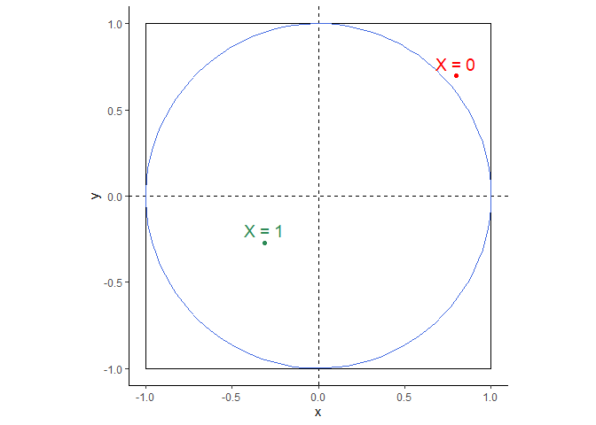

```r
ggplot() +
  geom_polygon(aes(x, y), fill = NA, color = 'black') +
  coord_fixed() + theme_classic() +
  geom_vline(xintercept = 0, linetype = 'dashed') +
  geom_hline(yintercept = 0, linetype = 'dashed') +
  geom_path(aes(cos(z), sin(z)), color = 'royalblue') +
  geom_point(aes(c(-0.314, 0.8), c(-0.271, 0.7)), color = c('seagreen', 'red')) +
  geom_text(aes(-0.314, -0.2, label = 'X = 1'), size = 5, color = 'seagreen') +
  geom_text(aes(0.8, 0.77, label = 'X = 0'), size = 5, color = 'red')
```

Нетрудно видеть, что с помощью площади круга

[figure not shown]

и площади квадрата

[figure not shown]

можно вычислить

[figure not shown]

Если же мы выберем достаточно много точек из квадрата, то доля попавших в круг точек будет некоторым приближением (оценкой) искомой вероятности!

```r
X <- runif(1e3, -1, 1)
Y <- runif(1e3, -1, 1)
in_circle <- (X ^ 2 + Y ^ 2) < 1
```

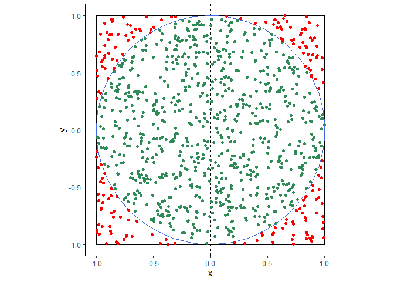

```r
ggplot() +
  geom_polygon(aes(x, y), fill = NA, color = 'black') +
  coord_fixed() + theme_classic() +
  geom_vline(xintercept = 0, linetype = 'dashed') +
  geom_hline(yintercept = 0, linetype = 'dashed') +
  geom_path(aes(cos(z), sin(z)), color = 'royalblue') +
  geom_point(aes(X[in_circle], Y[in_circle]), color = 'seagreen') +
  geom_point(aes(X[!in_circle], Y[!in_circle]), color = 'red')
```

Для начала сгенерируем реализацию

[figure not shown]

(псевдо)случайных равномерно распредленных на отрезке

[figure not shown]

величин для x-координаты и для y-координаты.

```r
X <- runif(n = 1e4, min = -1, max = 1)
Y <- runif(1e4, -1, 1)
```

Для этого мы воспользовались функцией `runif`, генерирующей выборку из равномерного распределения. В документации к ней можно найти, как вычислять функцию плотности, распределения, а также квантили. Документацию к любой функции можно вызвать в консоли при помощи вопросительного знака перед ее названием: `?runif`

И вообще:

[figure not shown]

```r
knitr::include_graphics('meme.png')
```

Читайте документацию!

Точка лежит в круге, если сумма квадратов ее координат меньше единицы. Но как нам это быстро посчитать для 10000 точек? Воспользуемся тем же принципом, который лежит в основе следующей строчки кода:

```r
c(1, 2, 3, 4, 5) > 3
```

```
## [1] FALSE FALSE FALSE  TRUE  TRUE
```

Операция сравнения была проведена для *каждого элемента* вектора, и на выходе мы получили вектор такой же длины.

Аналогично операции над векторами одинаковой длины, будут производиться для каждой *пары* элементов, имеющих одинаковый индекс (пары первых элементов, пары вторых и т.д.)

```r
a <- c(1, 2, 3, 4)
b <- c(2, 2, 2, 2)
b ^ a
```

```
## [1]  2  4  8 16
```

Таким образом, мы можем быстро посчитать, какие точки находятся в круге, сначала найдя расстояние от центра окружности, а затем сравнив его с единицей:

```r
distance <- X ^ 2 + Y ^ 2
distance[1:5]
```

```
## [1] 0.1242660 0.8413127 0.8745991 0.8742188 0.3355467
```

```r
in_circle <- distance < 1
in_circle[1:5]
```

```
## [1] TRUE TRUE TRUE TRUE TRUE
```

Значение `TRUE` говорит нам о том, что случайная точка оказалась внутри окружности. Доля таких точек - оценка искомой вероятности, а именно

[figure not shown]

```r
mean(in_circle)
```

```
## [1] 0.7844
```

Расчитаем на основе этой вероятности оценку для

[figure not shown]

```r
4 * mean(in_circle)
```

```
## [1] 3.1376
```

```r
pi
```

```
## [1] 3.141593
```

Описанная выше процедура называется **метод Монте-Карло**: приближенное вычисление вероятности при помощи многократной генерации случайных величин.

В одномерном случае он не так полезен из-за высокой погрешности. Чтобы в этом убедиться, можете попробовать приблизить

[figure not shown]

при помощи выборки размера

[figure not shown]

или даже

[figure not shown]

. Получится ли получить хотя бы три верных знака после запятой?

Однако в многомерном случае Монте-Карло - зачастую единственный выход, поскольку вычислительная сложность обычных алгоритмов нахождения объемов тел растет экспоненциально с увеличением размерности задачи.

## Задание.

Посчитайте методом Монте-Карло приближенное значение

[figure not shown]

. Используйте

[figure not shown]

случайных точкек, выбранных из квардрата с вершинами

[figure not shown]

. Попадание под график какой функции необходимо использовать?

# Задача 2. Метод обратной функции.

Продолжим работу с равномерно распределенными случайными величинами. Оказывается, что с их помощью можно получать случайные величины с произвольной плотностью. Сразу обратимся к примеру.

Пусть

[figure not shown]

. Какое распределение будет иметь

[figure not shown]

?

Для начала заметим, что (в силу симметрии)

[figure not shown]

имеет такое же распределение, как и

[figure not shown]

. Будем искать распределение

[figure not shown]

.

Остается лишь вывести, что

[figure not shown]

Справа получаем функцию распределения

[figure not shown]

в точке

[figure not shown]

. Т.к.

[figure not shown]

,

[figure not shown]

Иными словами,

[figure not shown]

, а значит и

[figure not shown]

, имеет экспоненциальное распределение!

Убедимся в этом при помощи симуляции:

```r
y <- runif(1e4, 0, 1)
log_y <- -log(y)
```

Построим гистограмму и плотность экспоненциального распределения поверх нее:

```r
t <- seq(0, 10, length.out = 100) # точки, в которых будем считать плотность
```

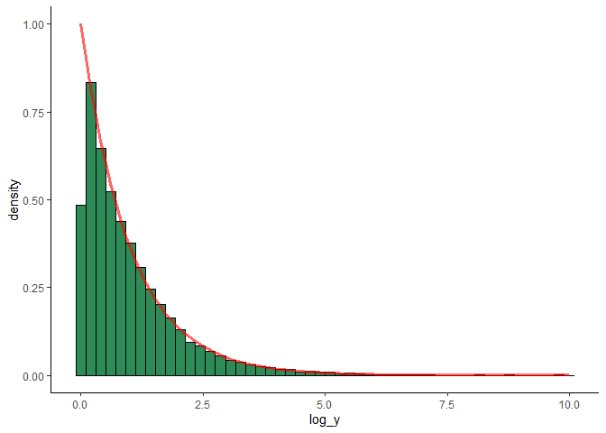

```r
ggplot() + theme_classic() +

  geom_histogram(mapping = aes(x = log_y, y = ..density..), # чтобы площадь под гистограммой суммировалась в единицу
                          bins = 50, color = 'black', fill = 'seagreen') +

  geom_line(mapping = aes(x = t, y = dexp(t, rate = 1)),
            color = 'red', size = 1.1, alpha = 0.6)
```

Итак, гистограмма отлично подходит под плотность, что и требовалось доказать.

В общем случае, если у нас есть случайная величина

[figure not shown]

с функцией распределения

[figure not shown]

, то достаточно приравнять

[figure not shown]

и выразить

[figure not shown]

. Тогда полученное справа выражение - функция от

[figure not shown]

- будет иметь распределение такое же, как и

[figure not shown]

.

Проблемы могут возникнуть лишь в точках, в которых

[figure not shown]

не определена однозначно (например, в случае дискретных случайных величин). Тогда потребуется дополнительно определить, какое значение будет принимать новая случайная величина в каждой из таких точек.

## Задание.

Создайте *нормальную* выборку при помощи равномерно распределенных случайных величин. Как посчитать функцию, обратную функции распределения (**quantile function**)? Ответ поможет найти чтение документации к функции `dexp()` из графика выше 😋

Для полученной выборки постройте аналогичную гистограмму с графиком плотности.

# Задача 3. Распределение редких событий.

Ниже представлены данные о бомбардировках области южного Лондона во время Второй мировой войны *(источник: R.D. Clarke. An application of the Poisson distribution. Journal of the Institute of Actuaries, 72:48, 1946; Table 1 on page 481. Faculty and Institute of Actuaries.)*. Эта область была разделена на

[figure not shown]

квадратов со стороной

[figure not shown]

метров, и для каждого квадрата было подсчитано число попавших туда бомб.

```r
number_of_hits <- 0:7
number_of_squares <- c(229, 211, 93, 35, 7, 0, 0, 1)
```

Были ли бомбардировки *абсолютно случайны*? Признаком этого может служить тот факт, что число бомб в отдельном квадрате подчиняется распределению Пуассона.

Чтобы получить первоначальное представление о том, насколько верно наше предположение, проведем симуляцию: выберем

[figure not shown]

равномерно распределенных точек из квадрата

[figure not shown]

и для каждого внутреннего квадрата

[figure not shown]

посчитаем число попавших туда бомб:

```r
n = 24
point_x <- runif(537, 0, n)
point_y <- runif(537, 0, n)
```

Обратите внимание, как много квадратов, где вообще нет ни одной точки и где всего одна точка:

```r
#число попаданий в каждый квадрат (для покраски)
index <- n * floor(point_y) + floor(point_x)
index_for_table <- c(index, 0:(n ^ 2 - 1)) # чтобы выловить нули, снизу вычитаем 1 из всего
number_of_hits_sim <- tabulate(index_for_table + 1) - 1 # + 1 потому что нужны positive integers

#вершины квадратов
x <- c()
y <- c()

for (index in 0:(n ^ 2 - 1)) {
  x0 <- index %% n
  y0 <- index %/% n
  x = c(x, x0, x0, x0 + 1, x0 + 1)
  y = c(y, y0, y0 + 1, y0 + 1, y0)
}

d <- data.frame(x = x, y = y,
                group = rep(0:(n ^ 2 - 1), each = 4),
                fill = rep(as.character(number_of_hits_sim), each = 4))
```

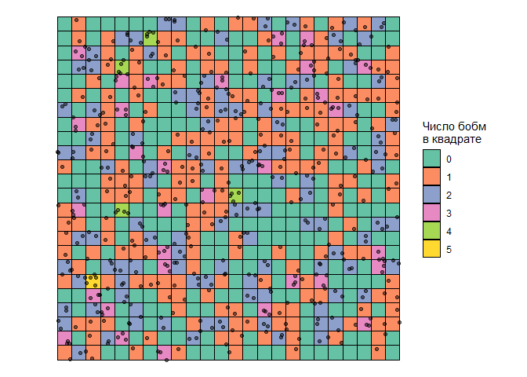

```r
ggplot() +

  geom_polygon(data = d, aes(x, y, group = group, fill = fill),
               color = 'black', size = 0.3) +

  scale_fill_brewer(palette = 'Set2') +

  geom_point(aes(point_x, point_y), alpha = 0.5) +

  coord_fixed() + theme_void() +

  labs(fill = 'Число бобм\nв квадрате')
```

Для симулированных данных оценим параметр распределения Пуассона и найдем с помощью него теоретические частоты:

```r
freq_sim <- tabulate(c(0:7, number_of_hits_sim) + 1) - 1 # опять ловим нули и делаем поправку из-за positive integers
freq_sim <- freq_sim / sum(freq_sim)
l_hat <- mean(number_of_hits_sim)
freq_pois <- dpois(number_of_hits, l_hat)
```

```r
knitr::kable(data.frame('Число попаданий' = number_of_hits,
                        'Число квадратов' = freq_sim * 576,
                        'Число квадратов реальные данные' = number_of_squares,
                        'Наблюдаемая частота' = freq_sim,
                        'Теоретическая вероятность' = freq_pois),
             align = 'l', digits = 3)
```

| Число.попаданий | Число.квадратов | Число.квадратов.реальные.данные | Наблюдаемая.частота | Теоретическая.вероятность |
| --- | --- | --- | --- | --- |
| 0 | 228 | 229 | 0.396 | 0.394 |
| 1 | 202 | 211 | 0.351 | 0.367 |
| 2 | 109 | 93 | 0.189 | 0.171 |
| 3 | 32 | 35 | 0.056 | 0.053 |
| 4 | 4 | 7 | 0.007 | 0.012 |
| 5 | 1 | 0 | 0.002 | 0.002 |
| 6 | 0 | 0 | 0.000 | 0.000 |
| 7 | 0 | 1 | 0.000 | 0.000 |

Итак, результаты симуляции похожи на реальные данные (хотя полного совпадения не произошло, но этого и не следовало ожидать). В то же время наблюдаемые частоты хорошо согласуются с вероятностями, посчитанными на основе оценки параметра Пуассоновского распределения.

## Задание.

Ваша задача - определить, похожи ли представленные выше реальные данные на выборку из распределения Пуассона. Для этого оцените параметр распределения

[figure not shown]

(любым удобным способом) и сравните теоретические вероятности с наблюдаемыми, нанеся их на один график.

# Задача 4. Неравенство Йенсена и несмещенные оценки.

Продолжим работу с распределением Пуассона. Пусть у нас есть выборка из него, и мы хотели бы оценить

[figure not shown]

. Сравним две стратегии:

- вероятность можно оценить как относительную частоту события

[figure not shown]

  среди всех реализаций случайной величины.
- можно оценить параметр

[figure not shown]

  , а с помощью него - вероятность как

[figure not shown]

В первом случае, очевидно, такая оценка будет несмещенной (по той же самой причине, по которой частота выпадения единицы - несмещенная оценка параметра распределения Бернулли).

А что же во втором случае? Проведем симуляцию и посмотрим, как будет вести себя оценка. Не будем забывать, что оценка - это случайная величина, и поэтому мы можем симулировать ее реализации.

```r
lambd <- 3.14
realizations <- sapply(1:1e4, function(x) {exp( -mean(rpois(n = 10, lambda = lambd)))})
```

Функция `sapply()` в данном случае - лишь удобное сокращение, которое позволяет не пользоваться синтаксисом цикла.

Построим гистограмму из реализаций оценки и нанесем на нее истинное значение вероятности

[figure not shown]

и среднее значение полученной выборки при помощи `geom_vline()`:

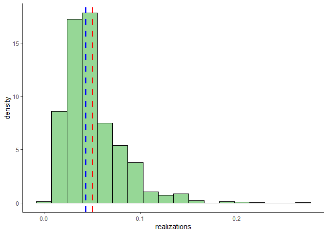

```r
ggplot() + theme_classic() +
  geom_histogram(mapping = aes(x = realizations, y = ..density..),
                 color = 'black', fill = 'palegreen3', bins = 18, alpha = 0.8) +
  #вертикальные линии
  geom_vline(xintercept = exp(-3.14),
             linetype = 'dashed', size = 1.1, color = 'blue') +

  geom_vline(xintercept = mean(realizations),
             linetype = 'dashed', size = 1.1, color = 'red')
```

Получается, что в среднем наша оценка завышала истинную вероятность. Это иллюстрирует вероятностная версия известного **неравенства Йенсена**:

[figure not shown]

для *выпуклой* функции

[figure not shown]

.

В нашем случае выпуклая функция - это

[figure not shown]

,

[figure not shown]

, и слева в неравенстве стоит выпуклое преобразвание математического ожидания -

[figure not shown]

.

Мы же пытаемся оценить его помощью

[figure not shown]

, хотя это (согласно закону больших чисел и свойствам сходимости случайных величин) - несмещенная оценка для правой части, которая в нашем случае строго больше (из-за строгой выпуклости

[figure not shown]

).

Однако следует отметить, что у данной стратегии есть и свои плюсы. Рассмотрим выборку из распределения Пуассона с параметром

[figure not shown]

:

```r
pois <- c(2, 2, 2, 4, 5, 2, 6, 3, 5, 1)
```

Несмещенная оценка для

[figure not shown]

в этом случае будет равна нулю! Дело в том, что реальная вероятность

[figure not shown]

для такого значения параметра не превосходит

[figure not shown]

, и в десяти испытаниях событие

[figure not shown]

не произошло ни разу. Смещенная же оценка равна:

```r
exp(-mean(pois))
```

```
## [1] 0.0407622
```

и это гораздо ближе к истине. Данный пример должен напомнить, что несмещенность означает отсутствие *систематического* отклонения оценки от истинного значения. Из-за случайности для отдельно взятой выборки смещенная оценка может быть точнее.

## Задание.

Выберите какие-нибудь значения

[figure not shown]

и

[figure not shown]

и *несмещенно* оцените стандартное отклонение для нормальной выборки при помощи оценки

[figure not shown]

где

[figure not shown]

- корень из несмещенной оценки дисперсии (по выборке его считает функция `sd()`), а

[figure not shown]

Гамма функцию

[figure not shown]

можно посчитать с помощью `gamma()`.

[figure not shown]

раз сгенерируйте нормальную выборку размера

[figure not shown]

(чтобы смещение было еще довольно заметно) и на ее основе посчитайте несмещенную оценку. Сделать это можно циклом или с помощью `sapply()`.

Затем постройте аналогичную гистограмму и вертикальные линии - с настоящим стандартным отклонением и со средним из выборки оценок.